# Machine Learning Models - Regression

Karim Carroum Sanz

*Karim Carroum Sanz - karim.carroum01@estudiant.upf.edu*

This script predicts the win rate of professional league of legends’ players using in-game performance statistics.

Note that this script contains several models, which means that there is a lot of raw information, which can make the script long and repetitive. This is just for completeness of the analysis, so that everything can be replicated, properly justified and documented. A brief summary of the results is accompanies this script. For a faster read, less focused on the details but more on the results, the reader can jump to the last sections of the script (using the table of contents), where the performance of the models is evaluated. After that, insights are extracted using the most relevant variables for this regression and the predicitons on the test set.

Set timer for the computation of all models, diagnostics and exploratory insights using the results.

```r
overall.start.time = Sys.time()
```

Load raw data.

```r
draw = read.csv("C:/Users/karim/OneDrive/Escritorio/playerstats.csv")[,1:27]
sprintf("The raw database has %i rows and %i variables", nrow(draw), ncol(draw))
```

```
## [1] "The raw database has 1603 rows and 27 variables"
```

# 1 Dealing with missing observations

## 1.1 Looking for patterns of missing observations

Check if there is any pattern behind the NA entries, so that we do not accidentally remove a relevant segment of the observations just because we lack data for specific features of them. First, we count the average and the total number of missing observations by variable.

```r
print("The proportions and totals of missing values in each of the variables are")
```

```
## [1] "The proportions and totals of missing values in each of the variables are"
```

```r
print(apply(apply(draw, 2, is.na), 2, mean)); print(apply(apply(draw, 2, is.na), 2, sum))
```

```
##        player        season        region        worlds      position
##    0.00000000    0.00000000    0.00000000    0.00000000    0.00000000
##         games      win_rate      win_lose win_cathegory           kda
##    0.00000000    0.00000000    0.00000000    0.00000000    0.00000000
##     avg_kills    avg_deaths   avg_assists           csm           gpm
##    0.00000000    0.00000000    0.00000000    0.00000000    0.08796007
##       dmg_pct       avg_dpm       avg_wpm      avg_wcpm      avg_vwpm
##    0.08796007    0.08796007    0.08796007    0.08796007    0.08796007
##          gd15         csd15         xpd15        fb_pct     fb_victim
##    0.26450405    0.26450405    0.26450405    0.26450405    0.26450405
##    dpm_deaths      dpm_gold
##    0.08796007    0.08796007
```

```
##        player        season        region        worlds      position
##             0             0             0             0             0
##         games      win_rate      win_lose win_cathegory           kda
##             0             0             0             0             0
##     avg_kills    avg_deaths   avg_assists           csm           gpm
##             0             0             0             0           141
##       dmg_pct       avg_dpm       avg_wpm      avg_wcpm      avg_vwpm
##           141           141           141           141           141
##          gd15         csd15         xpd15        fb_pct     fb_victim
##           424           424           424           424           424
##    dpm_deaths      dpm_gold
##           141           141
```

We also tabulate the missing observations for the problematic variables that display a high number of them, and by categorical variables that we think might help devising patterns of NAs.

```r
cat.problematic.vars = c("region","season"); problematic.vars = c("gpm","csd15")
for (problematic.var in problematic.vars){
  for (cat.problematic.var in cat.problematic.vars){
    print(sprintf("Number of missing observations for %s tabulated by %s:", problematic.var, cat.problematic.var))
    print(table(is.na(draw)[,problematic.var],draw[,cat.problematic.var])); cat("\n")
  }
}
```

```
## [1] "Number of missing observations for gpm tabulated by region:"
##
##         brazil chi  eu korea lms  na
##   FALSE    171 283 267   290 178 273
##   TRUE       0 141   0     0   0   0
##
## [1] "Number of missing observations for gpm tabulated by season:"
##
##           6   7   8   9  10
##   FALSE 164 245 341 343 369
##   TRUE   70  71   0   0   0
##
## [1] "Number of missing observations for csd15 tabulated by region:"
##
##         brazil chi  eu korea lms  na
##   FALSE    171   0 267   290 178 273
##   TRUE       0 424   0     0   0   0
##
## [1] "Number of missing observations for csd15 tabulated by season:"
##
##           6   7   8   9  10
##   FALSE 164 245 252 249 269
##   TRUE   70  71  89  94 100
```

We choose to delete columns that have NAs. Why?

```r
features.dropped = colnames(draw)[apply(apply(draw, 2, is.na), 2, sum) != 0]
`%notin%` = Negate(`%in%`); features.kept = colnames(draw)[colnames(draw) %notin% features.dropped]
sprintf("We keep %i features, and we drop %i features.", length(features.kept), length(features.dropped)); cat("\n")
```

```
## [1] "We keep 14 features, and we drop 13 features."
```

```r
print("The features kept are"); print(features.kept); cat("\n")
```

```
## [1] "The features kept are"
```

```
##  [1] "player"        "season"        "region"        "worlds"
##  [5] "position"      "games"         "win_rate"      "win_lose"
##  [9] "win_cathegory" "kda"           "avg_kills"     "avg_deaths"
## [13] "avg_assists"   "csm"
```

```r
print("The features dropped are"); print(features.dropped); cat("\n")
```

```
## [1] "The features dropped are"
```

```
##  [1] "gpm"        "dmg_pct"    "avg_dpm"    "avg_wpm"    "avg_wcpm"
##  [6] "avg_vwpm"   "gd15"       "csd15"      "xpd15"      "fb_pct"
## [11] "fb_victim"  "dpm_deaths" "dpm_gold"
```

Time to create a dataset that only contains the features that we keep.

```r
d = draw[,features.kept]; print(head(d))
```

```
##     player season region worlds position games win_rate win_lose win_cathegory
## 1  Froggen      7     na      0      MID    38    0.395        0           <40
## 2      957      6    chi      0      TOP    42    0.571        1         40-60
## 3   Lactea      8 brazil      0      ADC     7    0.286        0           <40
## 4   RooKie     10    chi      0      MID    39    0.718        1           60>
## 5     Athe      8    chi      0      MID    11    0.273        0           <40
## 6 Akaadian      8     na      0   JUNGLE    16    0.563        1         40-60
##   kda avg_kills avg_deaths avg_assists csm
## 1 3.1       3.5        2.3         3.4 9.2
## 2 4.7       2.1        2.2         8.3 7.2
## 3 2.0       3.7        3.4         3.1 9.9
## 4 3.4       4.1        3.2         6.9 7.6
## 5 3.7       2.5        2.1         5.2 8.9
## 6 2.8       1.3        2.1         4.6 5.2
```

Check if the new dataset contains missing observations.

```r
print("NA entries per column after removing conflictive variables"); apply(apply(d, 2, is.na), 2, sum)
```

```
## [1] "NA entries per column after removing conflictive variables"
```

```
##        player        season        region        worlds      position
##             0             0             0             0             0
##         games      win_rate      win_lose win_cathegory           kda
##             0             0             0             0             0
##     avg_kills    avg_deaths   avg_assists           csm
##             0             0             0             0
```

## 1.2 Creating a dataset with the target and the features

Create a dataset containing in the first column the target variable, and in the other columns continous and binary explanatory variables. Categorical variables with more than two categories are only used in the analysis section. I do not use the latter to train the models since they cannot be converted into numerical variables without incurring in high losses of accuracy of what they represent.

```r
dfeatures = d[,c("kda","avg_kills","avg_deaths","avg_assists","csm")] # Explanatory variables.
target.var = "win_rate"; dy = d[,target.var] # Target variable
dyf = d[,c(target.var,"kda","avg_kills","avg_deaths","avg_assists","csm")]; print(head(dyf))
```

```
##   win_rate kda avg_kills avg_deaths avg_assists csm
## 1    0.395 3.1       3.5        2.3         3.4 9.2
## 2    0.571 4.7       2.1        2.2         8.3 7.2
## 3    0.286 2.0       3.7        3.4         3.1 9.9
## 4    0.718 3.4       4.1        3.2         6.9 7.6
## 5    0.273 3.7       2.5        2.1         5.2 8.9
## 6    0.563 2.8       1.3        2.1         4.6 5.2
```

# 2 Dividing into Train and Test sets

The train set will be used to train the models via cross validated tunning of the parameters. The test set is also used to evaluate the relevance of the predictors in each model.

## 2.1 Create Train and Test sets

We define the sizes of the train and test sets to be the 50% of the whole dataset each.

```r
seed= 1; train.size = round(nrow(dyf)*0.5)
set.seed(seed); train.ind = sample((1:nrow(dyf)),train.size); train = dyf[train.ind,]; test = dyf[-train.ind,]
sprintf("Train set size is %i and test set size is %i.", nrow(train), nrow(test))
```

```
## [1] "Train set size is 802 and test set size is 801."
```

```r
target.train = train[,target.var]; target.test = test[,target.var] # Create a vector with the response for both sets, useful for the syntax of some functions.
```

## 2.2 Create a standardized version of the Train and Test sets

We scale the continuous predictors since it is required for a usually better performance of support vector machines and neural networks algorithms.

```r
non.continous.predictors = c(); continuous.predictors = colnames(dfeatures)[colnames(dfeatures) %notin% non.continous.predictors]
dyf.scaled = data.frame(dyf[,target.var],dyf[,non.continous.predictors],scale(dyf[,continuous.predictors])); colnames(dyf.scaled)[1] = target.var
if (length(non.continous.predictors) != 0){
  colnames(dyf.scaled)[2:(2+length(non.continous.predictors)-1)] = non.continous.predictors
}
train.scaled = dyf.scaled[train.ind,]; test.scaled = dyf.scaled[-train.ind,]; target.train.scaled = train.scaled[,target.var]; target.test.scaled = test.scaled[,target.var]
```

# 3 Machine Learning Models

Cross validations to tune parameters are done over 10 folds using the train set, but if we want to reduce the computational time this can be reduced. We use the test set to evaluate the performance of each optimally tuned model trained in the train set, reporting mean absolute error and mean squared error of the predictions, and to obtain variable importance measures.

## 3.1 Random Forests and Bagging

We cross validate random forests to tune the number of variables used at each split (parameter “mtry”) of the model. Since the cross validation also evaluates the case where we consider all the variables at each split, this approach also assesses bagging (mtry = $p$). We could also tune by optimal number of trees and other parameters, but the computational time scales up quickly with each extra parameter, and the gains resulting from tuning them are not as big as the ones from tunning mtry.

```r
require(randomForest); require(rfUtilities); require(tree); require(caret); require(pROC)
```

### 3.1.1 Parameter tunning

```r
set.seed(seed); rf.cv.start.time = Sys.time()
rf.cv = train(win_rate ~., data=train, method="rf", trControl=trainControl("cv", number = 10))
rf.cv.end.time = Sys.time(); rf.cv.total.time = rf.cv.end.time - rf.cv.start.time
sprintf("Random Forest parameter tunning via cross validation takes %2.f seconds to compute.", round(rf.cv.total.time,2))
```

```
## [1] "Random Forest parameter tunning via cross validation takes 38 seconds to compute."
```

```r
print(rf.cv)
```

```
## Random Forest
##
## 802 samples
##   5 predictor
##
## No pre-processing
## Resampling: Cross-Validated (10 fold)
## Summary of sample sizes: 722, 722, 722, 721, 722, 721, ...
## Resampling results across tuning parameters:
##
##   mtry  RMSE       Rsquared   MAE
##   2     0.1171041  0.5740469  0.09419928
##   3     0.1180443  0.5678430  0.09529081
##   5     0.1194663  0.5585800  0.09673715
##
## RMSE was used to select the optimal model using the smallest value.
## The final value used for the model was mtry = 2.
```

Fitting the random forest with the optimal mtry to the whole training set.

```r
rf = randomForest(win_rate~., data=dyf, subset=train.ind, mtry=as.integer(rf.cv$bestTune[1]), ntree=500, importance=TRUE); rf.importance = importance(rf)
```

### 3.1.2 Performance diagnostics

```r
rf.predicted = predict(rf,newdata=test); rf.errors = rf.predicted - test[,target.var]
rf.test.mse = mean((rf.errors)^2); rf.test.mae = mean(abs(rf.errors))
sprintf("Test root MSE = %.3f and Test MAE = %.3f using the cross-validated optimal mtry = %i.", round(sqrt(rf.test.mse),3), round(rf.test.mae,3), as.integer(rf.cv$bestTune[1]))
```

```
## [1] "Test root MSE = 0.119 and Test MAE = 0.094 using the cross-validated optimal mtry = 2."
```

## 3.2 Gradient Boosting Tree (Stochastic)

We cross validate to tune the optimal number of trees, learning rate and number of splits in each tree. This algorithm is fast, and thus tunning several parameters is computationally feasible for this task.

```r
require(xgboost); require(gbm)
```

### 3.2.1 Parameter tunning

```r
boost.cv.start.time = Sys.time(); set.seed(seed);
boost.cv = train(win_rate ~., data=train, method="gbm", trControl=trainControl("cv", number = 10))
boost.cv.end.time = Sys.time(); boost.cv.total.time = boost.cv.end.time - boost.cv.start.time
```

```r
sprintf("Cross validation of gradient boosting takes %.2f to compute", round(boost.cv.total.time, 2))
```

```
## [1] "Cross validation of gradient boosting takes 1.92 to compute"
```

```r
boost.cv$bestTune; boost.importance = varImp(boost.cv)
```

```
##   n.trees interaction.depth shrinkage n.minobsinnode
## 5     100                 2       0.1             10
```

### 3.2.2 Performance diagnostics

```r
boost.predicted = predict(boost.cv, newdata=test); boost.errors = boost.predicted - test[,target.var]
boost.test.mse = mean((boost.errors)^2); boost.test.mae = mean(abs(boost.errors))
sprintf("Test root MSE = %.3f and Test MAE = %.3f using the cross-validated optimal ntree = %i, learning rate = %.1f and number of splits = %i.",
         round(sqrt(boost.test.mse),3), round(boost.test.mae,3), as.integer(boost.cv$bestTune[1]), boost.cv$bestTune[3], as.integer(boost.cv$bestTune[2]))
```

```
## [1] "Test root MSE = 0.117 and Test MAE = 0.092 using the cross-validated optimal ntree = 100, learning rate = 0.1 and number of splits = 2."
```

## 3.3 Bayesian Regularized Neural Network

We tune by the number of hidden units of a single layer and bayesianely regularized neural network. Neural networks have a large number of parameters, and thus if we have more time, we can tune more of them, but again, the computational times scale up quickly. This is also the case for the neural network trained in the following model, which does not include a bayesian regularization, but tunes the weight decay in addition to the number of units.

```r
require(brnn)
```

### 3.3.1 Parameter tunning

```r
nn.bayesian.cv.start.time = Sys.time(); set.seed(seed);
nn.bayesian.cv = train(win_rate ~., data=train.scaled, method="brnn", trControl=trainControl("cv", number = 10))
nn.bayesian.cv.end.time = Sys.time(); nn.bayesian.cv.total.time = nn.bayesian.cv.end.time - nn.bayesian.cv.start.time
```

```r
sprintf("Cross validation of the bayesian neural network takes %.2f to compute", round(nn.bayesian.cv.total.time, 2))
```

```
## [1] "Cross validation of the bayesian neural network takes 2.09 to compute"
```

```r
nn.bayesian.cv$bestTune; nn.bayesian.importance = varImp(nn.bayesian.cv)
```

```
##   neurons
## 3       3
```

### 3.3.2 Performance diagnostics

```r
nn.bayesian.predicted = predict(nn.bayesian.cv, newdata=test.scaled); nn.bayesian.errors = nn.bayesian.predicted - test.scaled[,target.var]
nn.bayesian.test.mse = mean((nn.bayesian.errors)^2); nn.bayesian.test.mae = mean(abs(nn.bayesian.errors))
sprintf("Test root MSE = %.3f and Test MAE = %.3f using the cross-validated optimal number of hidden units %i.",
        round(sqrt(nn.bayesian.test.mse),3), round(nn.bayesian.test.mae,3), as.integer(nn.bayesian.cv$bestTune[1]))
```

```
## [1] "Test root MSE = 0.116 and Test MAE = 0.092 using the cross-validated optimal number of hidden units 3."
```

## 3.4 Simple Neural Network

Single layer neural network tuned by the number of units and the weight decay parameter.

```r
require(neuralnet)
```

### 3.4.1 Parameter tunning

```r
nn.single.cv.start.time = Sys.time(); set.seed(seed);
nn.single.cv = train(win_rate ~., data=train.scaled, method="nnet", trControl=trainControl("cv", number = 10))
nn.single.cv.end.time = Sys.time(); nn.single.cv.total.time = nn.single.cv.end.time - nn.single.cv.start.time
```

```r
sprintf("Cross validation of the neural network takes %.2f to compute", round(nn.single.cv.total.time, 2))
```

```
## [1] "Cross validation of the neural network takes 7.14 to compute"
```

```r
nn.single.cv$bestTune; nn.single.importance = varImp(nn.single.cv)
```

```
##   size decay
## 4    3     0
```

### 3.4.2 Performance diagnostics

```r
nn.single.predicted = predict(nn.single.cv, newdata=test.scaled); nn.single.errors = nn.single.predicted - test.scaled[,target.var]
nn.single.test.mse = mean((nn.single.errors)^2); nn.single.test.mae = mean(abs(nn.single.errors))
sprintf("Test root MSE = %.3f and Test MAE = %.3f using the cross-validated optimal number of hidden units %i and weight decay %.2f.",
        round(sqrt(nn.single.test.mse),3), round(nn.single.test.mae,3), as.integer(nn.single.cv$bestTune[1]),nn.single.cv$bestTune[2])
```

```
## [1] "Test root MSE = 0.116 and Test MAE = 0.091 using the cross-validated optimal number of hidden units 3 and weight decay 0.00."
```

## 3.5 Bayesian LASSO

Bayesian LASSO creates predictions using the mean of the posterior distributions but sets some parameters specifically to zero based on the tuning parameter sparsity. For example, when sparsity = .5, only coefficients where at least half the posterior estimates are nonzero are used.

```r
require(monomvn)
```

### 3.5.1 Parameter tunning

```r
lasso.bayesian.cv.start.time = Sys.time(); set.seed(seed);
lasso.bayesian.cv = train(win_rate ~., data=train, method="blasso", trControl=trainControl("cv", number = 10))
lasso.bayesian.cv.end.time = Sys.time(); lasso.bayesian.cv.total.time = lasso.bayesian.cv.end.time - lasso.bayesian.cv.start.time
```

```r
sprintf("Cross validation of the neural network takes %.2f to compute", round(lasso.bayesian.cv.total.time, 2))
```

```
## [1] "Cross validation of the neural network takes 5.44 to compute"
```

```r
lasso.bayesian.cv$bestTune; lasso.bayesian.importance = varImp(lasso.bayesian.cv)
```

```
##   sparsity
## 3      0.7
```

### 3.5.2 Performance diagnostics

```r
lasso.bayesian.predicted = predict(lasso.bayesian.cv, newdata=test); lasso.bayesian.errors = lasso.bayesian.predicted - test[,target.var]
lasso.bayesian.test.mse = mean((lasso.bayesian.errors)^2); lasso.bayesian.test.mae = mean(abs(lasso.bayesian.errors))
sprintf("Test root MSE = %.3f and Test MAE = %.3f using the cross-validated optimal sparsity %.2f.",
        round(sqrt(lasso.bayesian.test.mse),3), round(lasso.bayesian.test.mae,3), lasso.bayesian.cv$bestTune[1])
```

```
## [1] "Test root MSE = 0.116 and Test MAE = 0.092 using the cross-validated optimal sparsity 0.70."
```

# 4 Model Comparison

Comparison of the predictive accuracy.

```r
rootmse = c(sqrt(rf.test.mse),sqrt(boost.test.mse),sqrt(nn.bayesian.test.mse),sqrt(nn.single.test.mse),sqrt(lasso.bayesian.test.mse))
names(rootmse) = c("RandomForest", "BoostedGradient", "NeuralNetwork.Bayesian", "NeuralNetwork.SingleLayer", "BayesianLasso")
mae = c(rf.test.mae,boost.test.mae,nn.bayesian.test.mae,nn.single.test.mae,lasso.bayesian.test.mae)
names(mae) = c("RandomForest", "BoostedGradient", "Neural Network.Bayesian", "NeuralNetwork.SingleLayer", "BayesianLasso")
print(rootmse); print(mae)
```

```
##              RandomForest           BoostedGradient    NeuralNetwork.Bayesian
##                 0.1192838                 0.1172010                 0.1163303
## NeuralNetwork.SingleLayer             BayesianLasso
##                 0.1158074                 0.1159776
```

```
##              RandomForest           BoostedGradient   Neural Network.Bayesian
##                0.09384319                0.09191953                0.09155338
## NeuralNetwork.SingleLayer             BayesianLasso
##                0.09144031                0.09154138
```

Which model/s predicts better?

```r
best.model.mse = names(rootmse[which.min(rootmse)]); best.model.mae = names(mae[which.min(mae)])
sprintf("The model with the lowest Test MSE is %s with %.3f", best.model.mse, min(rootmse))
```

```
## [1] "The model with the lowest Test MSE is NeuralNetwork.SingleLayer with 0.116"
```

```r
sprintf("The model with the lowest Test MAE is %s with %.3f", best.model.mae, min(mae))
```

```
## [1] "The model with the lowest Test MAE is NeuralNetwork.SingleLayer with 0.091"
```

Create a data frame with the predictions for the test set of all models, and select those of the model that reports the best mean absolute error.

```r
predictions = data.frame("RandomForest" = rf.predicted, "BoostedGradient" = boost.predicted, "NeuralNetwork-Bayesian" = nn.bayesian.predicted, "NeuralNetwork-SingleLayer" = nn.single.predicted, "BayesianLasso" = lasso.bayesian.predicted)
best.model = best.model.mae # I choose MAE as the most representative accuracy metric. sprintf
best.predictions = predictions[,names(mae)[which.min(mae)]]
```

# 5 Extracting Insights

Analysis using the most relevant variables for the regression, jointly with the predictions of the models, and clustering by predictions and other insightful categorical variables. Using a subset of the most relevant variables is an efficient way of extracting insights. If time allows, we can also use the rest of the predictors.

## 5.1 Defining the most relevant variables

First, we take a look at the variable importance scores.

```r
print(rf.importance); print(boost.importance); print(nn.bayesian.importance); print(nn.single.importance)
```

```
##              %IncMSE IncNodePurity
## kda         54.88614     10.585319
## avg_kills   26.06187      2.776083
## avg_deaths  29.79240      3.430087
## avg_assists 38.42500      5.194194
## csm         23.71747      2.404017
```

```
## gbm variable importance
##
##             Overall
## kda         100.000
## avg_assists  21.332
## csm           5.612
## avg_kills     5.352
## avg_deaths    0.000
```

```
## loess r-squared variable importance
##
##             Overall
## kda          100.00
## avg_assists   52.86
## avg_deaths    50.02
## avg_kills     14.76
## csm            0.00
```

```
## nnet variable importance
##
##             Overall
## kda          100.00
## avg_assists   55.27
## avg_deaths    37.56
## csm           35.66
## avg_kills      0.00
```

```r
important.vars = c("avg_deaths","csm","avg_kills"); print("The variables that are more relevant for predicting are"); print(important.vars)
```

```
## [1] "The variables that are more relevant for predicting are"
```

```
## [1] "avg_deaths" "csm"        "avg_kills"
```

```r
# If desired, we can use all the predictors in the analysis with the code line --> important.vars = colnames(test[,2:ncol(test)])
```

## 5.2 Create a categorical response

To cluster observations by levels of predictions done by the model, we create a categorical variable. Such clustering is complementary of the non-clustered analysis.

For simplicity, the intervals are set to be of equal range. Note that this can yield to having considerably different lengths of observations at each interval.

```r
divide = function(x, nintervals = 5){ # Function to create equally divided intervals of the range of predictions. Will be used in the following function.
  range.x = max(x) - min(x); interval.range = range.x/nintervals; intervals.lower = rep(0,nintervals); intervals.lower[1] = min(x)
  for (interval in 2:nintervals){
    intervals.lower[interval] = intervals.lower[interval-1] + interval.range
  }
  return(intervals.lower)
}

cont.to.cat = function(x){ # Function to convert a continuous variable to a categorical with five categories, from very low to very high.
  intervals.mark = divide(x = x, nintervals = 5) # The function divide is the one created above.
  converted = rep(NA,nrow(test))
  converted[x <= intervals.mark[2]] = "Very Low"
  converted[x > intervals.mark[2] & x <= intervals.mark[3]] = "Low"
  converted[x > intervals.mark[3] & x <= intervals.mark[4]] = "Medium"
  converted[x > intervals.mark[4] & x <= intervals.mark[5]] = "High"
  converted[x > intervals.mark[5]] = "Very High"
  converted = as.factor(converted)
  return(list("converted"=converted, "intervals.mark"=intervals.mark[2:length(intervals.mark)]))
}
```

Check how the conversion of the predictors to a categorical variable turns out.

```r
predictions.categories = cont.to.cat(best.predictions)$converted; predictions.categories.intervals.marks = cont.to.cat(best.predictions)$intervals.mark
print(sprintf("The marks of the intervals for the test predictions of %s are", target.var)); print(predictions.categories.intervals.marks)
```

```
## [1] "The marks of the intervals for the test predictions of win_rate are"
```

```
## [1] 0.2700384 0.4110667 0.5520951 0.6931234
```

```r
head(data.frame(best.predictions, predictions.categories), 20) # If everything has worked out properly, there should not be any NAs.
```

```
##    best.predictions predictions.categories
## 1         0.3862195                    Low
## 2         0.7322179              Very High
## 3         0.5946333                   High
## 4         0.4371460                 Medium
## 5         0.7578602              Very High
## 6         0.2322152               Very Low
## 7         0.3725760                    Low
## 8         0.6343761                   High
## 9         0.6315972                   High
## 10        0.3876434                    Low
## 11        0.6018321                   High
## 12        0.7543593              Very High
## 13        0.6461667                   High
## 14        0.4346567                 Medium
## 15        0.5054386                 Medium
## 16        0.4159967                 Medium
## 17        0.7556238              Very High
## 18        0.4724345                 Medium
## 19        0.3871288                    Low
## 20        0.2740688                    Low
```

## 5.3 Quantitative and qualitative summaries

### 5.3.1 Continous variables

Note that all the variables analysed here are also analysed in the following subsection after converting them into categorical. An analysis on the latter is less accurate numerically, but can be qualitatively more insightful. The reader can skip this subsection if she or he is more concerned with the latter type of results.

```r
variables.of.interest = c(important.vars)
for (variable in variables.of.interest){
  means = aggregate(test[,variable], list(predictions.categories), mean); medians = aggregate(test[,variable], list(predictions.categories), median)
  sds = aggregate(test[,variable], list(predictions.categories), sd); maxs = aggregate(test[,variable], list(predictions.categories), max)
  mins = aggregate(test[,variable], list(predictions.categories), min); counts = aggregate(test[,variable], list(predictions.categories), length)
  summary.stats = data.frame(means,medians[,2],sds[,2],maxs[,2],mins[,2],counts[,2])
  colnames(summary.stats) = c("levels.of.prediction","mean","median","standard dev","max","min","count")
  print(sprintf("Summary statistics of %s by levels of prediction are", variable)); print(summary.stats); cat("\n")
}
```

```
## [1] "Summary statistics of avg_deaths by levels of prediction are"
##   levels.of.prediction     mean median standard dev max min count
## 1                 High 2.024227    2.0    0.4911451 3.2 0.8   194
## 2                  Low 2.829231    2.8    0.5170465 4.1 1.7   195
## 3               Medium 2.368687    2.3    0.5300395 4.1 1.2   297
## 4            Very High 1.869444    1.8    0.4549072 2.9 0.9    72
## 5             Very Low 3.118605    3.2    0.6310444 4.6 1.9    43
##
## [1] "Summary statistics of csm by levels of prediction are"
##   levels.of.prediction     mean median standard dev  max min count
## 1                 High 6.535052    8.0     3.124831 10.7 0.7   194
## 2                  Low 6.011795    7.4     3.042333 10.3 0.6   195
## 3               Medium 6.558923    8.0     3.076468 10.7 0.6   297
## 4            Very High 5.702778    5.8     3.063321  9.8 0.5    72
## 5             Very Low 5.790698    7.5     3.093219 10.0 0.7    43
##
## [1] "Summary statistics of avg_kills by levels of prediction are"
##   levels.of.prediction     mean median standard dev max min count
## 1                 High 2.708763    2.9    1.2443762 5.8 0.3   194
## 2                  Low 1.886154    2.0    0.8602104 3.9 0.2   195
## 3               Medium 2.385522    2.5    1.1029870 5.4 0.1   297
## 4            Very High 2.895833    3.0    1.4425562 6.4 0.5    72
## 5             Very Low 1.493023    1.5    0.7484573 3.1 0.4    43
```

### 5.3.2 Cathegorical variables

First, we convert the continous variables into categorical with 5 categories, from very low to very high.

```r
conts.non.converted = important.vars[sapply(sapply(test[,important.vars], unique), length)>5] # This ensures avoiding converting numerical variables with less than 5 distinct values/categories to a categorical of 5 values.
conts.converted = data.frame(rep(NA,nrow(test)))
for (variable in conts.non.converted){
  conts.converted[,variable] = cont.to.cat(test[,variable])$converted
}
conts.converted = conts.converted[,2:ncol(conts.converted)]; print(head(conts.converted))
```

```
##   avg_deaths       csm avg_kills
## 1        Low Very High    Medium
## 2        Low      High       Low
## 3       High      High      High
## 4        Low    Medium  Very Low
## 5        Low  Very Low  Very Low
## 6  Very High       Low       Low
```

```r
other.categoric.vars = c("position","region","season"); variables.of.interest.cat = data.frame(conts.converted, d[-train.ind,other.categoric.vars])
for (variable in colnames(variables.of.interest.cat)){
  print(sprintf("2D Table of categories of predictions and levels of %s", variable))
  print(table(predictions.categories, variables.of.interest.cat[,variable])); cat("\n")
}
```

```
## [1] "2D Table of categories of predictions and levels of avg_deaths"
##
## predictions.categories High Low Medium Very High Very Low
##              High         3 111     47         0       33
##              Low         59  36     96         4        0
##              Medium      31 137    106         2       21
##              Very High    0  45     10         0       17
##              Very Low    21   7     11         4        0
##
## [1] "2D Table of categories of predictions and levels of csm"
##
## predictions.categories High Low Medium Very High Very Low
##              High        47   7     32        69       39
##              Low         66  18     20        46       45
##              Medium      79  20     41       102       55
##              Very High   18   6     16        15       17
##              Very Low    18   3      6         5       11
##
## [1] "2D Table of categories of predictions and levels of avg_kills"
##
## predictions.categories High Low Medium Very High Very Low
##              High        32  42     78         3       39
##              Low          1 104     36         0       54
##              Medium      23 116     99         1       58
##              Very High   20  11     21         3       17
##              Very Low     0  22      5         0       16
##
## [1] "2D Table of categories of predictions and levels of position"
##
## predictions.categories ADC JUNGLE MID SUPPORT TOP
##              High       50     39  39      39  27
##              Low        18     36  35      45  61
##              Medium     71     61  60      55  50
##              Very High  11     22  17      17   5
##              Very Low    4      9   5      11  14
##
## [1] "2D Table of categories of predictions and levels of region"
##
## predictions.categories brazil chi eu korea lms na
##              High          28  60 32    26  22 26
##              Low           20  43 35    39  18 40
##              Medium        34  77 44    64  28 50
##              Very High      7  26 12     7   5 15
##              Very Low       2   7 13    12   5  4
##
## [1] "2D Table of categories of predictions and levels of season"
##
## predictions.categories  6  7  8  9 10
##              High      28 37 50 41 38
##              Low       24 35 35 54 47
##              Medium    43 71 57 55 71
##              Very High 16 13  7 13 23
##              Very Low   3  5 14 12  9
```

### 5.3.3 Deeper insights

Here, we table the predicted categories with more than one level of categories. Note that, for a three dimensional table, the complexity and difficulty of the analysis scales up quickly. Therefore, here we might make only one or a few tables, and of no more than three dimensions.

```r
category1 = "region"; category2 = "position"; print(sprintf("3D Table of categories of predictions by levels of %s and %s", category1, category2))
```

```
## [1] "3D Table of categories of predictions by levels of region and position"
```

```r
print(table(predictions.categories, d[-train.ind,category1], d[-train.ind,category2]))
```

```
## , ,  = ADC
##
##
## predictions.categories brazil chi eu korea lms na
##              High           8  12 11     4   5 10
##              Low            3   5  3     4   1  2
##              Medium         6  21  5    23   6 10
##              Very High      2   4  1     0   2  2
##              Very Low       0   1  2     1   0  0
##
## , ,  = JUNGLE
##
##
## predictions.categories brazil chi eu korea lms na
##              High           1  17  5     9   5  2
##              Low            1   9 12     3   3  8
##              Medium        12  11  8    12   4 14
##              Very High      3   7  5     3   1  3
##              Very Low       0   2  3     2   2  0
##
## , ,  = MID
##
##
## predictions.categories brazil chi eu korea lms na
##              High           5   9  5     9   5  6
##              Low            3   6  8     6   6  6
##              Medium         6  16  9    13   6 10
##              Very High      1   7  1     2   1  5
##              Very Low       0   0  2     2   0  1
##
## , ,  = SUPPORT
##
##
## predictions.categories brazil chi eu korea lms na
##              High           6  11  8     4   6  4
##              Low            7  11  4     9   2 12
##              Medium         3  14  9     9  10 10
##              Very High      1   5  4     1   1  5
##              Very Low       0   2  3     4   1  1
##
## , ,  = TOP
##
##
## predictions.categories brazil chi eu korea lms na
##              High           8  11  3     0   1  4
##              Low            6  12  8    17   6 12
##              Medium         7  15 13     7   2  6
##              Very High      0   3  1     1   0  0
##              Very Low       2   2  3     3   2  2
```

## 5.4 Correlation analysis

```r
require(ggplot2); require(GGally)
```

The following plot clusters by leves of prediction using different colors.

```r
considered.vars = c(important.vars, other.categoric.vars); groups = predictions.categories # Clusters the graphs by levels of predictions.
plot.ggpairs = ggpairs(d[-train.ind,c(target.var,considered.vars)], ggplot2::aes(colour=groups), diag = list(discrete="barDiag", lower = list(continuous = wrap("smooth", alpha = 0.3, size=0.1), discrete = "blank", combo="blank"), continuous = wrap("densityDiag", alpha=0.4)))
```

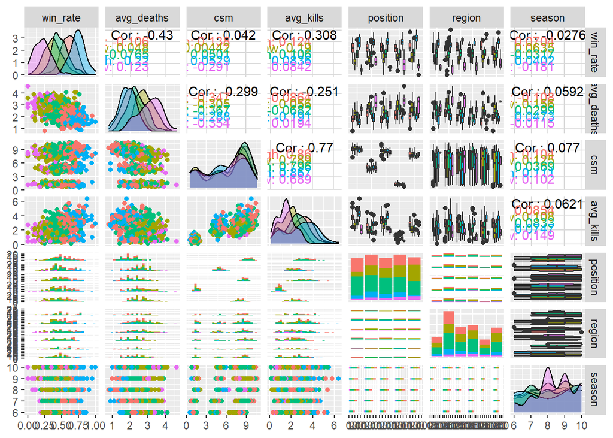

```r
print(plot.ggpairs)
```

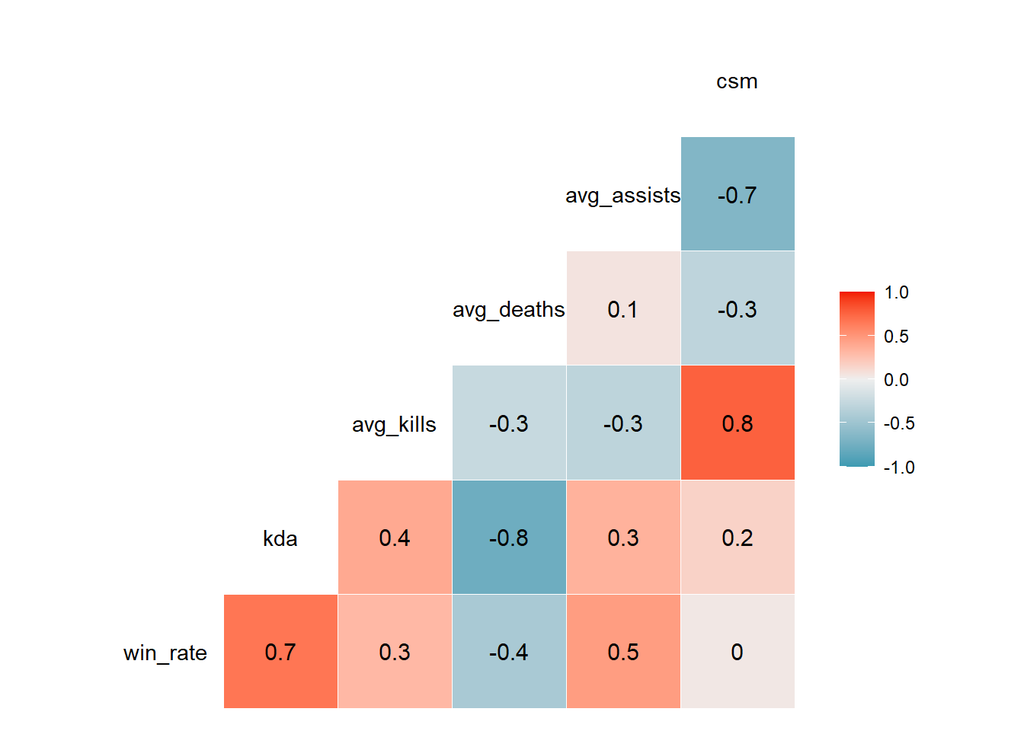

```r
ggcorr(test, palette = "RdBu", label = TRUE)
```

```r
overall.end.time = Sys.time(); overall.total.time = overall.end.time - overall.start.time
sprintf("Overall, it takes %.2f minutes to complete all the code in a computer with an Intel(R) Core(TM) i7-4510U CPU @ 2.00GHz 2.60 GHz processor and 16GB of RAM.", overall.total.time)
```

```
## [1] "Overall, it takes 1.57 minutes to complete all the code in a computer with an Intel(R) Core(TM) i7-4510U CPU @ 2.00GHz 2.60 GHz processor and 16GB of RAM."
```